# vbhavya_PeerCommentary_Amandafw_05

Amanda Wu

2023-11-21

# Preliminaries

```r
library(curl)
```

```r
library(ggplot2)
library(nlraa)

dat <- read.csv(curl("https://raw.githubusercontent.com/fuzzyatelin/fuzzyatelin.github.io/master/AN588_Fall23/KamilarAndCooperData.csv"), header = TRUE, sep = ",", stringsAsFactors = FALSE)
head(dat)
```

```
##               Scientific_Name          Family          Genus      Species
## 1 Allenopithecus_nigroviridis Cercopithecidae Allenopithecus nigroviridis
## 2         Allocebus_trichotis Cercopithecidae      Allocebus    trichotis
## 3           Alouatta_belzebul        Atelidae       Alouatta     belzebul
## 4             Alouatta_caraya        Atelidae       Alouatta       caraya
## 5            Alouatta_guariba        Atelidae       Alouatta      guariba
## 6           Alouatta_palliata        Atelidae       Alouatta     palliata
##   Brain_Size_Species_Mean Brain_Size_Female_Mean   Brain_size_Ref
## 1                   58.02                  53.70 Isler et al 2008
## 2                      NA                     NA
## 3                   52.84                  51.19 Isler et al 2008
## 4                   52.63                  47.80 Isler et al 2008
## 5                   51.70                  49.08 Isler et al 2008
## 6                   49.88                  48.04 Isler et al 2008
##   Body_mass_male_mean Body_mass_female_mean Mass_Dimorphism
```

[output cut: 62 more lines]

**NOTES** This is really smart how you combined the read.csv & curl function together onto one line of code! - AW

## Question 1: Using the “KamilarAndCooperData.csv” dataset, run a linear regression looking at log(HomeRange_km2) in relation to log(Body_mass_female_mean) and report your β coeffiecients (slope and intercept).

```r
m <- lm(log(HomeRange_km2) ~ log(Body_mass_female_mean), data = dat)
m
```

```
##
## Call:
## lm(formula = log(HomeRange_km2) ~ log(Body_mass_female_mean),
##     data = dat)
##
## Coefficients:
##                (Intercept)  log(Body_mass_female_mean)
##                     -9.441                       1.036
```

I picked the type I linear regression for this because I think the two variables of home range and female body mass don’t necessarily co-vary some other process. A type II linear regression would probably not be required

The coefficients of the OLS regression are -9.441 for beta0, the intercept and 1.036 for the slope, making the equation: log(HomeRange_km2) = 1.036*log(Body_mass_female_mean) - 9.441

**NOTES** This is exactly how I had done this too and I think I got similar answers. Nice job with your notes! - AW

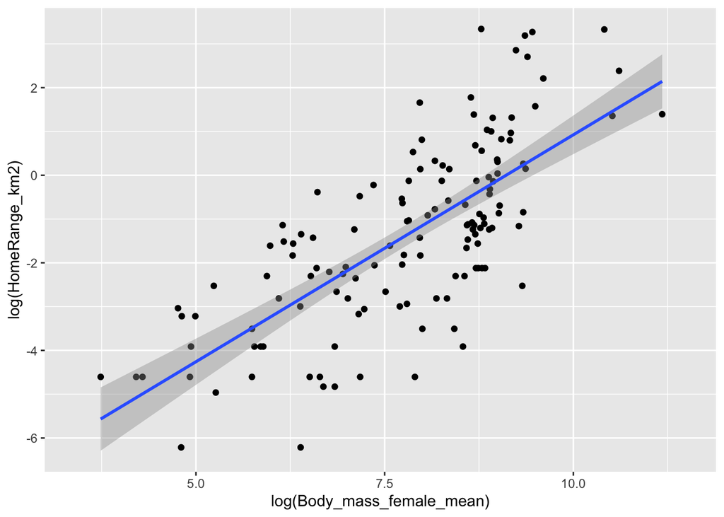

```r
g <- ggplot(data = dat, aes(x = log(Body_mass_female_mean), log(HomeRange_km2)))
g <- g + geom_point()
g <- g + geom_smooth(method = "lm", formula = y ~ x)
g #This is to check if the linear regression looks good or not
```